# Lab2_Bumblebee

William Brickowski, Rachael Robinson, Manasi Raol, Brady Kiesling

1/24/2019

## GROUP SECTION

Group Name: Bumblebee

Group Goals: Learning to use R, applying statistics to real world problems, and learning how to use GitHub

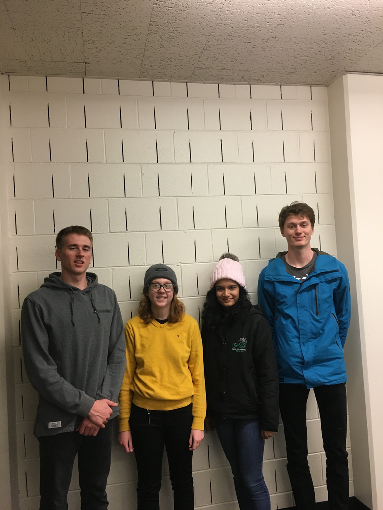

## William Brickowski

[figure not shown]

Question I would analyze data to answer: I am currently pursuing a certificate in quantitative finance through the Leeds School of Business. I am quite interested in the financial markets and am interested in analyzing data on various portoflios with respect to market conditions in order to analyze how various factors affect portfolio returns.

Six months after graduation: I would like to begin my career as a trader working for a firm that employs quantitative and algorithmic strategies.

Five years after graduation: I would like to be in the place where I can be own my own business, perhaps start my own fund.

Greatest career accompishment: I interned with Franklin Templeton Investments last summer which was a major stepping stone in the progression of my career.

In this course: In this course I hope to learn how to use GitHub efficiently, learning how to work with my team, and apply interesting data analysis methods.

Fun fact: I grew up in Doha, Qatar!